# Homework 3

Neslihan Caliskan

2/24/2021

# Homework 03

You will analyze data looking at the relationship between **green reputation** and three personality traits–**compassion**, **intellectual curiosity**, and **openness to experiences**. The dataset includes data from **students** and **non-students**.

```r
library(tidyverse)
```

```r
library(ggplot2)
library(ggdist)
```

```r
dictionary <- readr::read_csv(("green_dictionary.csv"))
green_data <- readr::read_csv(("green_data.csv"))
```

For your assignment, do the following.

1. Inspect the item responses (e.g., with graphs or by summarizing distinct values). Is anything unusual?

Get the summaries of each data file

```r
dictionary %>%
  summarize(dictionary)
```

```
## # A tibble: 36 x 4
##    Item   Content                                         Options         Keying
##    <chr>  <chr>                                           <chr>            <dbl>
##  1 green1 Overall, I am regarded as an environmentally c… 1-5; SD, D, NA…      1
##  2 green2 I am not particularly known for protecting the… 1-5; SD, D, NA…     -1
##  3 green3 My friends know I enjoy nature.                 1-5; SD, D, NA…      1
##  4 green4 I have a reputation for living in harmony with… 1-5; SD, D, NA…      1
##  5 green5 Among people I know, I seem to be the one most… 1-5; SD, D, NA…      1
##  6 comp1  I feel others' emotions.                        1-5; SD, D, NA…      1
##  7 comp2  I inquire about others' well-being.             1-5; SD, D, NA…      1
##  8 comp3  I sympathize with others' feelings.             1-5; SD, D, NA…      1
##  9 comp4  I take an interest in other people's lives.     1-5; SD, D, NA…      1
## 10 comp5  I like to do things for others.                 1-5; SD, D, NA…      1
## # … with 26 more rows
```

```r
#getting rid of the -99 values

green_data_new <- green_data %>%
                na_if("-99")


reversed <- dictionary %>%
  filter(Keying == -1) %>%
  pull(Item)

green_datar <- green_data_new %>%
  mutate(across(all_of(reversed),
                ~ recode(.x, "1"= 5,"2" = 4,"4" = 2,"5"= 1 ),
                .names = "{.col}r"))

green_data_new$student <- recode_factor(green_data_new$student, '1' = "Non-student", '2' = "Student", .default = NULL)


#There are -99 s in the data file that needs to be recoded
```

2. Compute total scores for the four scales. Recode variables as needed.

```r
green_datar %>%
  rowwise() %>%
  mutate(green_tot = sum(c_across(green1:green5), na.rm = TRUE),
         comp_tot = sum(c_across(comp1:comp10r), na.rm = TRUE),
         intel_tot = sum(c_across(intel1:intel10r), na.rm = TRUE),
         open_tot = sum(c_across(open1:open10r), na.rm = TRUE))
```

```
## # A tibble: 373 x 55
## # Rowwise:
##    id    green1 green2 green3 green4 green5 comp1 comp2 comp3 comp4 comp5 comp6
##    <chr>  <dbl>  <dbl>  <dbl>  <dbl>  <dbl> <dbl> <dbl> <dbl> <dbl> <dbl> <dbl>
##  1 9099       4      2      5      4      3     2     5     4     4     2     2
##  2 6275       3      5      3      3      1     4     5     4     5     5     1
##  3 8116       4      2      5      4      3     4     5     5     4     5     1
##  4 8586       4      3      5      4      3     4     5     5     4     5     1
##  5 0406       3      2      4      4      4     4     4     4     4     4     2
##  6 5645       4      3      4      4      3     5     5     5     4     4     2
##  7 3788       1      1      1      1      1     3     3     3     3     3     3
##  8 8424       4      3      2      2      2     1     1     1     2     2     4
##  9 8450       4      2      3      5      2     4     4     4     4     4     1
## 10 0512       4      2      5      5      4     5     2     5     4     2     2
## # … with 363 more rows, and 43 more variables: comp7 <dbl>, comp8 <dbl>,
## #   comp9 <dbl>, comp10 <dbl>, intel1 <dbl>, intel2 <dbl>, intel3 <dbl>,
## #   intel4 <dbl>, intel5 <dbl>, intel6 <dbl>, intel7 <dbl>, intel8 <dbl>,
## #   intel9 <dbl>, intel10 <dbl>, open1 <dbl>, open2 <dbl>, open3 <dbl>,
## #   open4 <dbl>, open5 <dbl>, open6 <dbl>, open7 <dbl>, open8 <dbl>,
## #   open9 <dbl>, open10 <dbl>, student <dbl>, green2r <dbl>, comp6r <dbl>,
## #   comp7r <dbl>, comp8r <dbl>, comp9r <dbl>, comp10r <dbl>, intel7r <dbl>,
## #   intel8r <dbl>, intel9r <dbl>, intel10r <dbl>, open7r <dbl>, open8r <dbl>,
## #   open9r <dbl>, open10r <dbl>, green_tot <dbl>, comp_tot <dbl>,
## #   intel_tot <dbl>, open_tot <dbl>
```

3. Rescale the variables so that they go from 0-100 instead of the original range. Name the recaled variables `*_pomp`.

```r
green_data_pomp <- green_datar %>%
  mutate(across(c(green1:open10),
         ~ recode(.x, "1"= 0,"2" = 25, "3" = 50, "4" = 75,"5"= 100),
                .names = "{.col}_pomp"))

print(green_data_pomp)
```

```
## # A tibble: 373 x 86
##    id    green1 green2 green3 green4 green5 comp1 comp2 comp3 comp4 comp5 comp6
##    <chr>  <dbl>  <dbl>  <dbl>  <dbl>  <dbl> <dbl> <dbl> <dbl> <dbl> <dbl> <dbl>
##  1 9099       4      2      5      4      3     2     5     4     4     2     2
##  2 6275       3      5      3      3      1     4     5     4     5     5     1
##  3 8116       4      2      5      4      3     4     5     5     4     5     1
##  4 8586       4      3      5      4      3     4     5     5     4     5     1
##  5 0406       3      2      4      4      4     4     4     4     4     4     2
##  6 5645       4      3      4      4      3     5     5     5     4     4     2
##  7 3788       1      1      1      1      1     3     3     3     3     3     3
##  8 8424       4      3      2      2      2     1     1     1     2     2     4
##  9 8450       4      2      3      5      2     4     4     4     4     4     1
## 10 0512       4      2      5      5      4     5     2     5     4     2     2
## # … with 363 more rows, and 74 more variables: comp7 <dbl>, comp8 <dbl>,
## #   comp9 <dbl>, comp10 <dbl>, intel1 <dbl>, intel2 <dbl>, intel3 <dbl>,
## #   intel4 <dbl>, intel5 <dbl>, intel6 <dbl>, intel7 <dbl>, intel8 <dbl>,
## #   intel9 <dbl>, intel10 <dbl>, open1 <dbl>, open2 <dbl>, open3 <dbl>,
## #   open4 <dbl>, open5 <dbl>, open6 <dbl>, open7 <dbl>, open8 <dbl>,
## #   open9 <dbl>, open10 <dbl>, student <dbl>, green2r <dbl>, comp6r <dbl>,
## #   comp7r <dbl>, comp8r <dbl>, comp9r <dbl>, comp10r <dbl>, intel7r <dbl>,
## #   intel8r <dbl>, intel9r <dbl>, intel10r <dbl>, open7r <dbl>, open8r <dbl>,
## #   open9r <dbl>, open10r <dbl>, green1_pomp <dbl>, green2_pomp <dbl>,
## #   green3_pomp <dbl>, green4_pomp <dbl>, green5_pomp <dbl>, comp1_pomp <dbl>,
## #   comp2_pomp <dbl>, comp3_pomp <dbl>, comp4_pomp <dbl>, comp5_pomp <dbl>,
## #   comp6_pomp <dbl>, comp7_pomp <dbl>, comp8_pomp <dbl>, comp9_pomp <dbl>,
## #   comp10_pomp <dbl>, intel1_pomp <dbl>, intel2_pomp <dbl>, intel3_pomp <dbl>,
## #   intel4_pomp <dbl>, intel5_pomp <dbl>, intel6_pomp <dbl>, intel7_pomp <dbl>,
## #   intel8_pomp <dbl>, intel9_pomp <dbl>, intel10_pomp <dbl>, open1_pomp <dbl>,
## #   open2_pomp <dbl>, open3_pomp <dbl>, open4_pomp <dbl>, open5_pomp <dbl>,
## #   open6_pomp <dbl>, open7_pomp <dbl>, open8_pomp <dbl>, open9_pomp <dbl>,
## #   open10_pomp <dbl>
```

```r
Av_green_data_pomp <- green_data_pomp %>%
  rowwise() %>%
  mutate(GM_pomp = mean(c_across(green1:green5), na.rm = TRUE),
         CM_pomp = mean(c_across(comp1:comp10r), na.rm = TRUE),
         IM_pomp = mean(c_across(intel1:intel10r), na.rm = TRUE),
         OM_pomp = mean(c_across(open1:open10r), na.rm = TRUE))
```

4. Make plots that illustrate the distributions of the 4 POMP-scored variables.

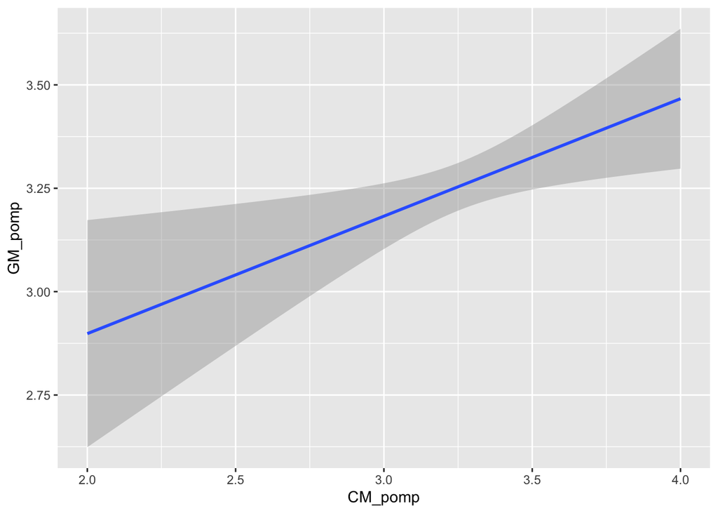

```r
Av_green_data_pomp %>%
ggplot() +
  aes(CM_pomp,GM_pomp) +
  geom_smooth(method = lm)
```

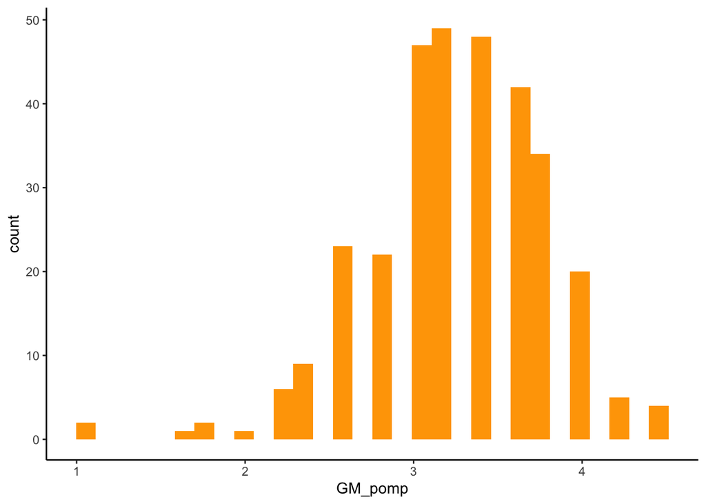

```r
Av_green_data_pomp %>%
ggplot() +
aes(x = GM_pomp) +
  geom_histogram(fill = "orange") +
  theme_classic()
```

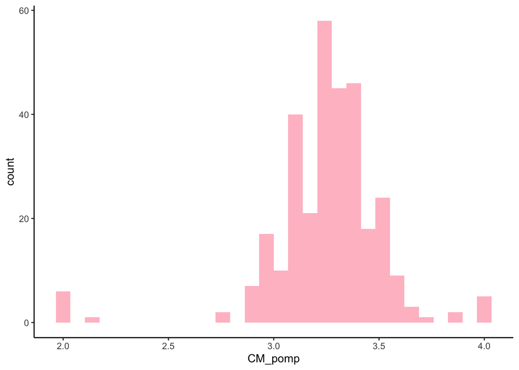

```r
Av_green_data_pomp %>%
ggplot() +
aes(x = CM_pomp) +
  geom_histogram(fill = "pink") +
  theme_classic()
```

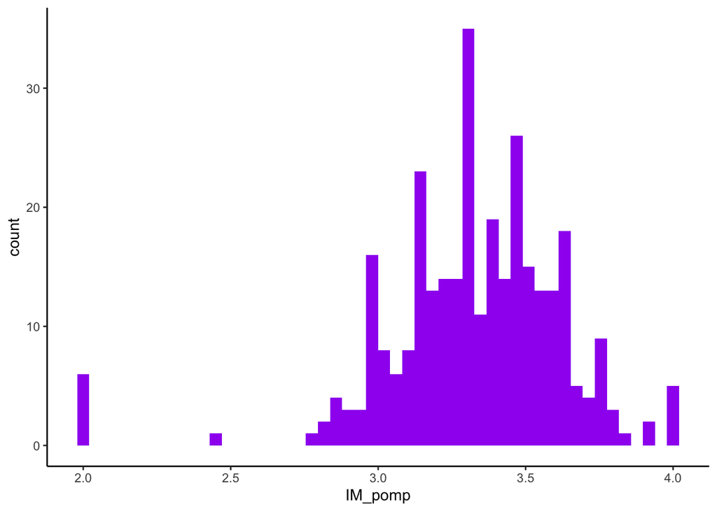

```r
Av_green_data_pomp %>%
ggplot() +
aes(x = IM_pomp) +
  geom_histogram(bins = 50, fill = "purple") +
  theme_classic()
```

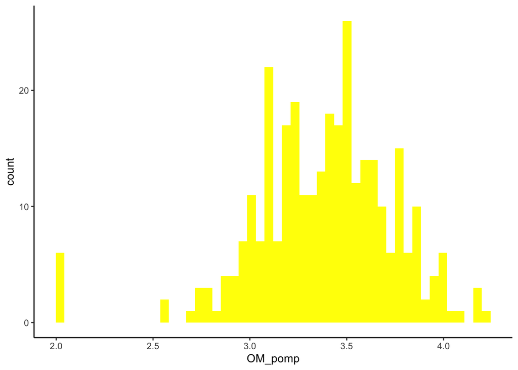

```r
Av_green_data_pomp %>%
ggplot() +
aes(x = OM_pomp) +
  geom_histogram(bins = 50, fill = "yellow") +
  theme_classic()
```

5. Make scatterplots showing the relationships between **green reputation** and each personality trait. Include trend lines for **students** and **non-students**. What do these plots show?

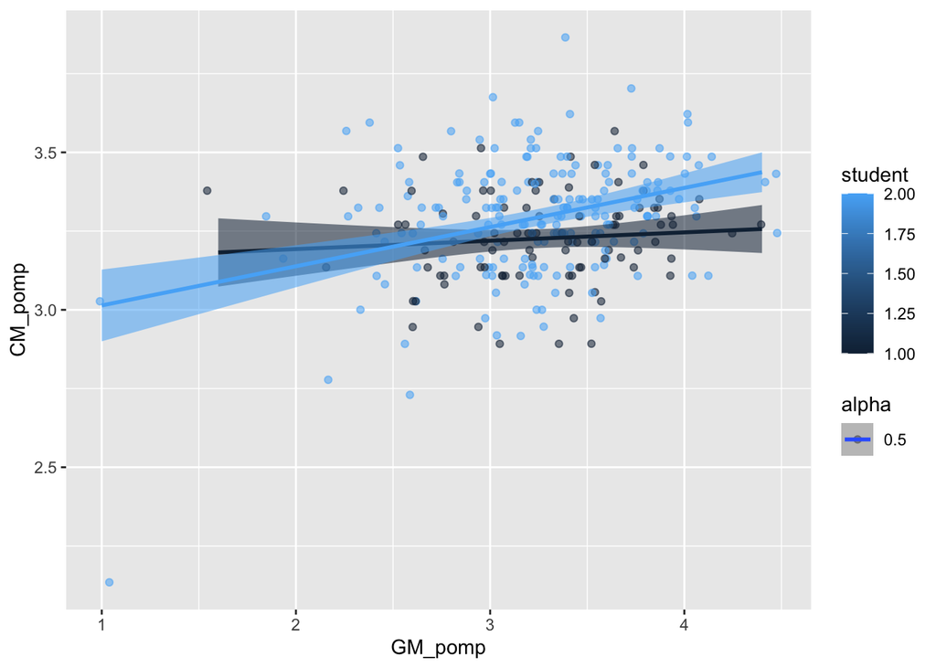

```r
Av_green_data_pomp %>%
  filter(!is.na(student)) %>%
  ggplot() +
  aes(y = CM_pomp,
      x = GM_pomp,
      group = student,
      color = student,
      fill = student,
      alpha = 0.5) +
  geom_jitter() +
  geom_smooth(method = "lm")
```

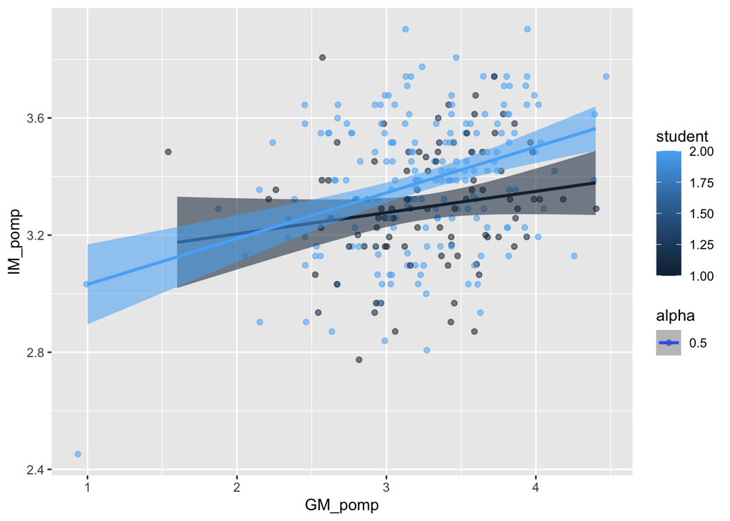

```r
Av_green_data_pomp %>%
  filter(!is.na(student)) %>%
  ggplot() +
  aes(y = IM_pomp,
      x = GM_pomp,
      group = student,
      color = student,
      fill = student,
      alpha = 0.5) +
  geom_jitter() +
  geom_smooth(method = "lm")
```

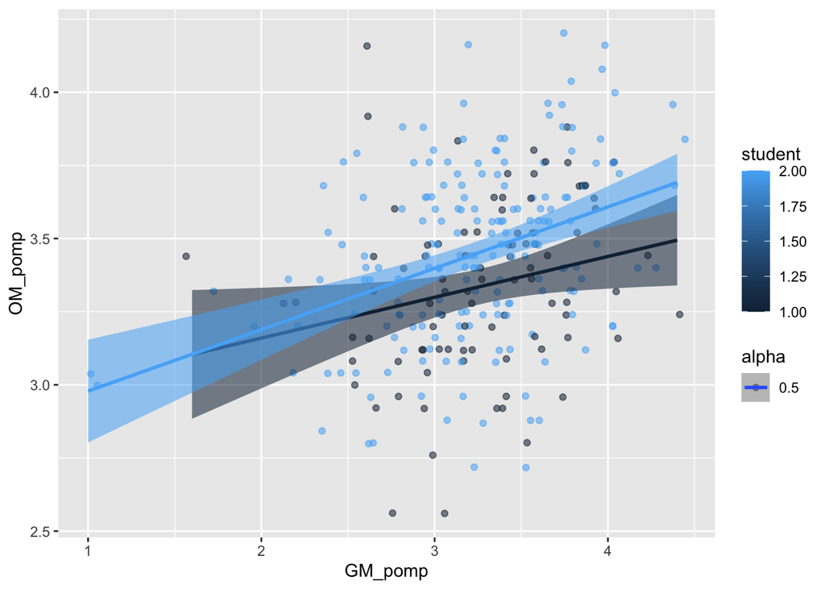

```r
Av_green_data_pomp %>%
  filter(!is.na(student)) %>%
  ggplot() +
  aes(y = OM_pomp,
      x = GM_pomp,
      group = student,
      color = student,
      fill = student,
      alpha = 0.5) +
  geom_jitter() +
  geom_smooth(method = "lm")
```

```r
#For all comparisons, the students had slightly higher scores but the difference was not large.
```

6. Compare **green reputation** for students and non-students using a **rainfall plot** (bar + density + data points).

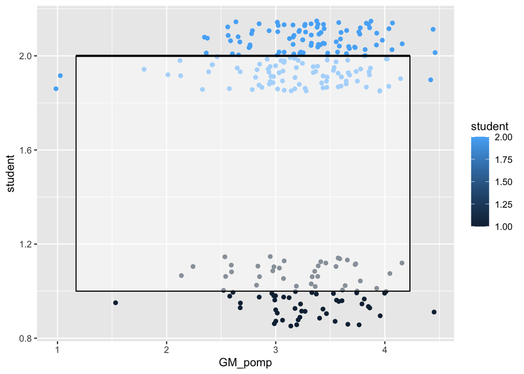

```r
ggplot(na.omit(Av_green_data_pomp)) +
  aes(x = GM_pomp,
      y = student,
      fill = student,
      color = student) +
  geom_jitter(height = .15) +
  geom_boxplot(color = "black",
               alpha = .5,
               width = .1,
               size =.5) +
  ggdist::stat_slab(height = 3,
                    color = "black",
                    size = .2,
                    alpha = .5,
                    position = position_nudge((y=.2)))
```

```r
#I couldn't run this code properly, could you help me figure out why?
```

7. Compute a summary table of means, SDs, medians, minima, and maxima for the four total scores for students and non-students.

In your assignment, prepare an RMarkdown file that includes both the coding and (for 4-7) narrative descriptions of your results.

```r
summary_GD <- Av_green_data_pomp %>%
  na.omit() %>%
  group_by(student) %>%
  summarize(across(c(GM_pomp, IM_pomp, CM_pomp, OM_pomp),
            list(
              Av = ~ mean(.x, na.rm = T),
              SD = ~ sd(.x, na.rm = T),
              Med = ~ median(.x, na.rm = T),
              Min = ~ min(.x, na.rm = T),
              Max = ~ max(.x, na.rm = T)
            )))

#Even though I ran the code to recode student names at the end it still showed them as 1 & 2.
#Students had higher average of oveal Openness scores. On average, non-students have higher environmental consciousness.
```

[output not shown]